[figure not shown]

ID-2

Identification

IDENTIFICATION

1. Identification

A: IDENTIFICATION

1. IDENTIFICATION NUMBER AND LABEL LOCATIONS

The V.I.N. (Vehicle Identification Numbers) is used to classify the vehicle.

• Positioning of the plate label for identification

(1) Vehicle identification number

(V.I.N.) (below right front floor car-

pet)

(3) Tire inflation pressure label

(driver’s side)

(5) VIN plate

(2) MVSS/CMVSS label (4) Model number label (attached to

right side of vehicle)

ID-00432

(1)

(5)

(3)

(2)

(4)

[figure not shown]

ID-3

Identification

IDENTIFICATION

• MVSS/CMVSS label

• Model number label

• Engine

• Automatic transmission

CVT

ID-00296

ID-00375

ID-00384

(2)

(1)

(1) Engine serial number (punch mark)

(2) Engine type (casting) crankcase upper side

ID-00435

(2)

(3)

(1)

(1) Label

(2) CVT type label

(3) Transmission serial No. label

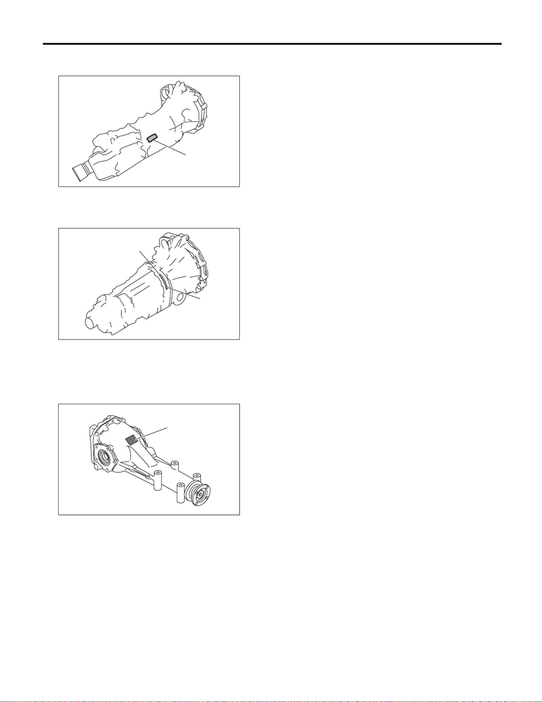

ID-4

Identification

IDENTIFICATION

• Manual transmission

Except for STI model

STI model

• Rear differential

T-type

(1)

ID-00414

(1) MT type and transmission serial number label

ID-00430

(1)

(2)

(1) Transmission serial No.

(2) MT type label

ID-00257

(1)

(1) Identification (white paint)

[figure not shown]

ID-5

Identification

IDENTIFICATION

2. MEANING OF V.I.N.

The meaning of the V.I.N. is as follows:

]JF1VA1A6XF9800001[

The starting and ending brackets ( ] [ ) are stop marks.

Digits Code Meaning Details

1 — 3 JF1 Manufacturer body area JF1: Passenger car, FHI made

4 V Car line V: WRX

5 A Body type A: Sedan

6 1 Displacement class 1: 2.0 L AWD DI turbo

2: 2.5 L AWD high power turbo

7 A Grade A: WRX (Lip-Spoiler Less)

B: WRX Keyless Access

C: WRX Premium

D: WRX Premium Moon Roof

E: WRX Premium Keyless Access Moon Roof

F: WRX Premium Moon Roof Harman/Kardon and Navi

G: WRX LTD Moon Roof

H: WRX LTD Moon Roof Keyless Access

J: WRX LTD Moon Roof Keyless Access Harman/Kardon and

Navi

K: STI (Wing Spoiler Less)

L: STI

M: STI Moon Roof

N: STI Keyless Access

P: STI Keyless Access Harman/Kardon and Navi

R: STI Keyless Access Moon Roof Harman/Kardon and Navi

S: STI LTD Moon Roof Harman/Kardon

T: STI LTD Keyless Access Moon Roof Harman/Kardon

U: STI LTD Keyless Access Moon Roof Harman/Kardon and

Navi

W: Special Edition

8 6 Restraint 6: Manual belts, dual airbag, side airbag for seat back, curtain

airbag for roof and driver’s knee airbag

9 X Check numbers X or 0 — 9

10 F Model year F: 2015MY

11 9 Transmission type 8: Full-time AWD CVT

9: Full-time AWD 6 speed MT

12 — 17 800001 Serial number 800001 — 899999

[figure not shown]

ID-6

Identification

IDENTIFICATION

3. MODEL NUMBER LABEL

The model number label indicates: the applied model, the option code, the trim code, the engine type, the

transmission type, and the exterior color code. This information is helpful when placing orders for parts.

VAGAYA6

The engine and transmission type are as follows.

• Engine

EJ257AG9LB

FA20FAZB9A

Digits Code Meaning Details

1V Series V: WRX

2 A Body type A: Sedan

3 G Total engine displace-

ment

Drive system

F: 2.5 L AWD high power turbo

G: 2.0 L AWD DI turbo

4 A Model year A: 2015MY

5 Y Destination Y: U.S., Canada

6A Grade A: WRX

B: WRX+L

C: WRX-Pre+L

D: WRX-LTD+L

E: STI

F: STI+W

H: STI-LTD+W

7 6 Transmission, fuel feed

system

6: DI turbo 6 speed MT AWD

8: DI turbo CVT AWD

H: MFI High power turbo 6 speed MT AWD

Digits Code Meaning Details

1 and 2 EJ Engine type symbol EJ: 4 cylinders

3 and 4 25 Displacement 25: 2.5 L

5 7 Fuel feed device 7: MFI High power turbo

6 A Exhaust regulations A: U.S. (FED)

7 G Mounted transmission G: 6MT

8 — 10 9LB Detailed specifications Used when ordering parts. For details, refer to the parts cata-

log.

Digits Code Meaning Details

1 and 2 FA Engine type symbol FA: 4 cylinder gasoline

3 and 4 20 Displacement 20: 2.0 L

5 F Valve train/fuel supply

system/steering

F: DOHC DIT (LH)

6 A Exhaust regulations A: For states not using California emission standards

7 Z Intake/exhaust system Z: Intake AVCS, exhaust AVCS, TGV, EGR

8 B Mounted transmission B: 6MT

H: CVT

9 and 10 9A Detailed specifications Used when ordering parts. For details, refer to the parts catalog.

[figure not shown]

ID-7

Identification

IDENTIFICATION

• Transmission

1. MT

TY751VB9CA

TY856UW9AA

2. CVT

TR690GB9BA

• Rear differential

Digits Code Meaning Details

1 T Transmission T: Transmission

2 Y Transmission system Y: Full-time AWD MT center differential

3 and 4 75 Distance between gear

center

75: Between main shaft and drive pinion

5 1 Classification 1: 6MT

6 V Transmission specifica-

tions

V: Full-time AWD single range 6MT with viscous coupling cen-

ter differential (without Auto Start Stop)

7 B Mounted engine B: 2.0 L DOHC turbo

8 — 10 9CA Detailed specifications Used when ordering parts. For details, refer to the parts cata-

log.

Digits Code Meaning Details

1 T Transmission T: Transmission

2 Y Transmission system Y: Full-time AWD MT center differential

3 and 4 85 Distance between gear

center

85: Between main shaft and drive pinion

5 6 Classification 6: 6MT

6 U Transmission specifica-

tions

U: Full-time AWD single range 6MT with driver’s control center

differential

7 W Mounted engine W: 2.5 L DOHC turbo

8 — 10 9AA Detailed specifications Used when ordering parts. For details, refer to the parts cata-

log.

Digits Code Meaning Details

1 T Transmission T: Transmission

2 R Transmission system R: Full-time AWD CVT

3 and 4 69 Distance between pul-

ley centers

69: Between pulley centers

5 0 Classification 0: CVT

6 G Transmission specifica-

tions

G: Without Auto Start Stop, with CVTF cooler (with warmer fea-

ture), without air cooler

7 B Mounted engine B: 2.0 L DOHC turbo

8 — 10 9BA Detailed specifications Used when ordering parts. For details, refer to the parts cata-

log.

Identification Reduction gear ratio LSD

B1 4.111 None

B2 3.900 None

H5 3.545 Torsen

[figure not shown]

ID-8

Identification

IDENTIFICATION

• Option code

JG

• 1-digit number

OP code 6 is a code for special edition.

• 2-digit number

OP code 1 is a code for special edition.

OP code JPRSTUWZ23456

18 in Tire & aluminum wheel (BBS) — — — — — — — — — —

Keyless access with push button start — — — — — — —

Harman navigation system — — — — — — — — —

Rearview camera —

LED headlight — — — —

Front fog light — —

Sunroof — — — — —

Auto light & auto wiper — — — — — — —

OP code G T W Y 1

Genuine leather seat — — —

Driver seat power seat — —

Driver’s seat and passenger’s seat

power seat

— — — — —

Driver’s seat and passenger’s seat

power seat (with memory)

— — — — —

Seat heater — —

Clear view package — —

[figure not shown]

RECOMMENDED MATERIALS

RM

Page

1. Recommended Materials ...........................................................................2